# Predicting Grades

**Comments to Critquers**

1. I do not understand how to interpret this. I’m off in my conclusion and I do not understand why.

## Background

### Overview

This analysis will be used to help you determine how to best succeed in Math 325: Intermediate Statistics. The main parts of this analysis that will be of interest to you are this section, `Summary`, and `Conclusion`. `Interpretation` goes into the technical details of how I came to my decision. I will be determining if a logistical test can indeed prove to be able to predict whether a student can receive an *A* or not.

$$H_0: \text{A logistical regression model will be a good fit or test to run for the data}$$
$$H_a: \text{A logistical regression model will not be a good fit}$$

`Data` shows the dataset and how it was obtained. The `Instructions` and `Class Activities` sections are for my use in understanding how to complete this analysis.

### Instructions

Use the `Train` data to create and validate your model. Once you have a good model, use the `Test` data to fill in the `FinalGrade` column with your predicted grades for each student.

Finally, state, graph, and interpret your logistic regression model as if you were speaking to a Math 325 student. Explain the effect on the odds of the student getting an A in Math 325 for each coefficient of your model. This explanation should help them realize which elements of the course are most important for increasing the probability that they get an A. Provide some sort of visualization of your model as well.

1. The html version of your completed analysis.

*Ensure this contains a statement of your final model, some sort of visualization of this model, and the interpretation of each coefficient’s effect on the odds. The other technical details and scratch-work can be placed at the bottom of the file.*

2. The Math325Grades_Test.csv data file with the “FinalGrade” column filled in with your predicted grade for each student in the form “A” or “Other”.

*A few hints on this… suppose you named the test data “Test” in R…*

*Test$FinalGrade <- ifelse(predict(yourglm, Test, type=“response”) > somedecimalvalue, “A”, “Other”)*

*write.csv(Test, “Test.csv”, row.names=FALSE)*

### Class Activities

#### Monday

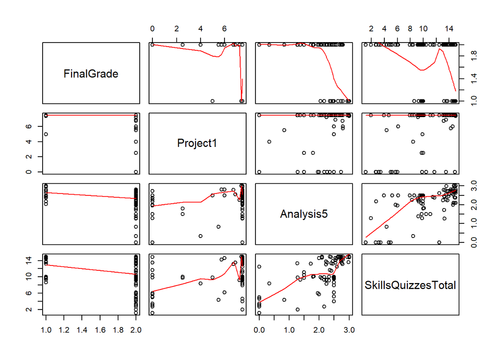

```r
pairs(grade325[,c("FinalGrade", "Project1", "Analysis5", "SkillsQuizzesTotal")], panel = panel.smooth)
```

```r
# What's the best column to use? Analysis5.
```

```r
glm1 <- glm(FinalGrade == "A" ~ Analysis5, data = grade325, family = binomial)
summary(glm1)
```

```
##
## Call:
## glm(formula = FinalGrade == "A" ~ Analysis5, family = binomial,
##     data = grade325)
##
## Deviance Residuals:
##      Min        1Q    Median        3Q       Max
## -1.84923  -0.75139  -0.00372   0.73771   2.11210
##
## Coefficients:
##             Estimate Std. Error z value Pr(>|z|)
## (Intercept)  -11.882      2.689  -4.419 9.93e-06 ***
## Analysis5      4.783      1.060   4.514 6.37e-06 ***
## ---
## Signif. codes:  0 '***' 0.001 '**' 0.01 '*' 0.05 '.' 0.1 ' ' 1
##
## (Dispersion parameter for binomial family taken to be 1)
##
##     Null deviance: 166.06  on 119  degrees of freedom
## Residual deviance: 113.94  on 118  degrees of freedom
## AIC: 117.94
##
## Number of Fisher Scoring iterations: 6
```

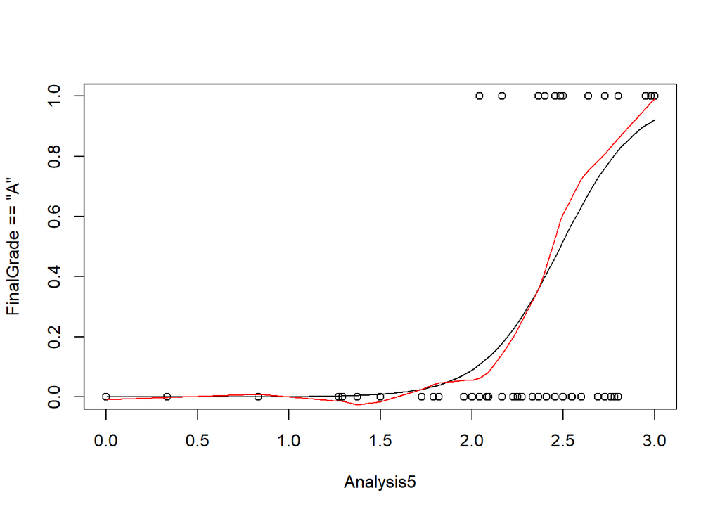

```r
b <- coef(glm1)
plot(FinalGrade == "A" ~ Analysis5, data = grade325)
curve(exp(b[1] + b[2]*x)/( 1 + exp(b[1] + b[2]*x) ), add = TRUE)
lines(lowess(grade325$Analysis5, grade325$FinalGrade == "A"), col = "red")
```

```r
util.lm <- lm(gasbill ~ month + I(month^2), data = Utilities)
summary(util.lm)
```

```
##
## Call:
## lm(formula = gasbill ~ month + I(month^2), data = Utilities)
##
## Residuals:
##      Min       1Q   Median       3Q      Max
## -117.440  -15.127   -0.692   10.528   86.617
##
## Coefficients:
##             Estimate Std. Error t value Pr(>|t|)
## (Intercept) 284.4558    10.5374   27.00   <2e-16 ***
## month       -76.6165     3.6609  -20.93   <2e-16 ***
## I(month^2)    5.4807     0.2712   20.21   <2e-16 ***
## ---
## Signif. codes:  0 '***' 0.001 '**' 0.01 '*' 0.05 '.' 0.1 ' ' 1
##
## Residual standard error: 30.48 on 114 degrees of freedom
## Multiple R-squared:  0.7937, Adjusted R-squared:  0.7901
## F-statistic: 219.3 on 2 and 114 DF,  p-value: < 2.2e-16
```

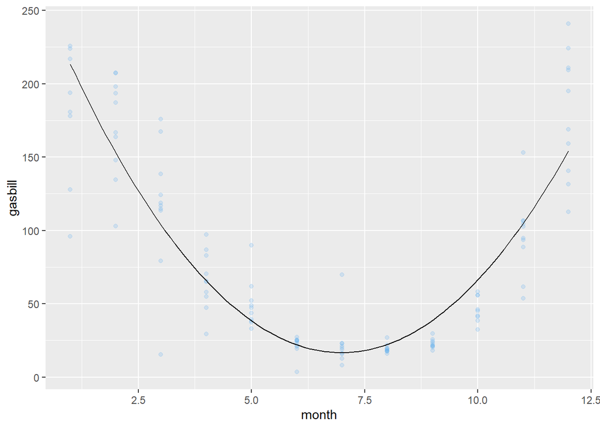

```r
b.1 <- util.lm$coefficients

Utilities %>%
  ggplot(aes(x = month, y = gasbill)) +
  geom_point(alpha = .2, col = "steelblue2") +
  stat_function(fun = function(x) b.1[1] + b.1[2]*x + b.1[3]*x^2)
```

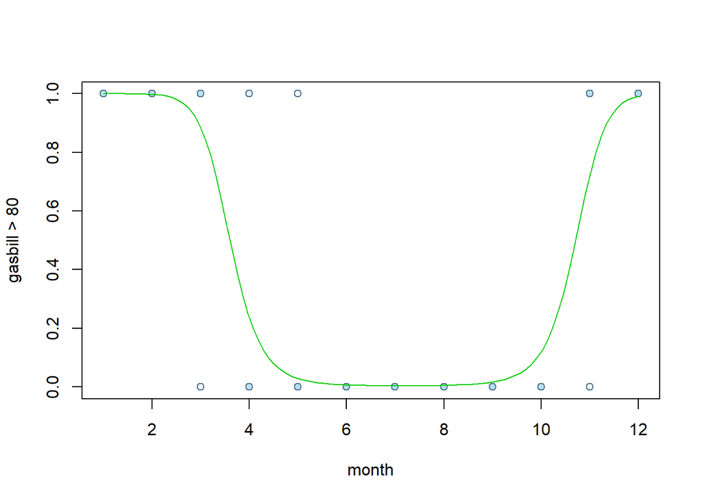

```r
plot(gasbill > 80 ~ month, data = Utilities, pch = 21, bg = rgb(.53, .8, .91, .1), col="skyblue4") #.1 creates the shading. The first three create the skyblue.

glm.gas <- glm(gasbill > 80 ~ month + I(month^2), data = Utilities, family = binomial)
b.glm <- glm.gas$coeff

curve(exp(b.glm[1] + b.glm[2]*x + b.glm[3]*x^2) / (1 + exp(b.glm[1] + b.glm[2]*x + b.glm[3]*x^2)), add=TRUE, col="green3")
```

#### Wednesday

Log of the odds is linear. What is odds and probability?

$Prob = \frac{Success}{Total}$ and $Odds = \frac{Success}{Failure}$

Success is `s`, failure is `f`, and total is `n`. $n$ - failure = success.

$\pi_i = \frac{s}{n}$ or $1 - \pi_i = 1 - \frac{s}{n} = \frac{n}{n} - \frac{s}{n} = \frac{n-s}{n} = \frac{f}{n}$

$\frac{\frac{s}{n}}{\frac{f}{n}} = \frac{s}{n} * \frac{n}{f} = \frac{s}{f} = \frac{\pi_i}{1 - \pi_i}$

1. If $\frac{3}{4}$ is a probability, what is the odds? $\frac{3}{1}$.
2. What is the smallest the odds could ever be? $\frac{0}{1}$ or zero because if the successes are zero then your odds have to be zero.
3. What’s the largest the odds can be? $\frac{2}{2}$ or one or infinity meaning that you never fail.
4. If your odds are one, what’s your probability? 50% because your it means that there is one success and one failure or $\frac{s}{n} = \frac{1}{2}$.

The log of the odds is interpretable. To undo a log you have to expedienate or exp() or $e = 2.7828...$. $log(odds) = e^{\beta_0 + \beta_1 X_i}$ has exp() added and becomes $odds = e^{\beta_0} e^{\beta_1 X_i}$. $e^{\beta_0}$ is the baseline. If $X_i$ is zero then $e^{\beta_1 X_i}$ becomes zero due to raising anything to the zero power is one and we are left with the baseline. If $X_i$ is 1, then we are able to see the change in the odds or $e^{\beta_0}$ or the baseline because we are left with $e^{\beta_1}$ when multiplying by one on the $X_i$.

We plot the probability, but we interpret the odds.

##### Predicting A in 425

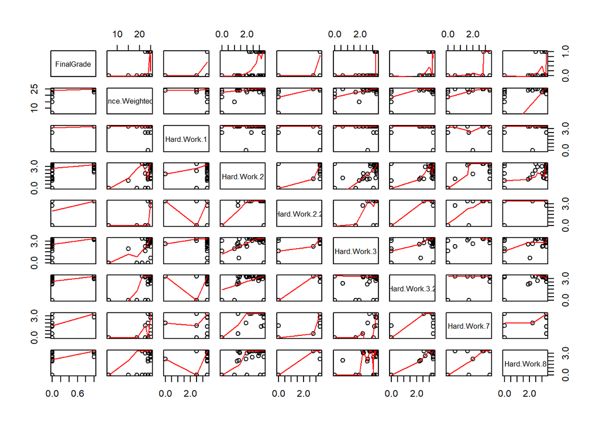

```r
#names(grade425)

grades425 <- grade425 %>%
  mutate(FinalGrade = ifelse(Final.Letter.Grade %in% c("A", "A-"), 1, 0))

pairs(grades425[, c(29,24, 11:17)], panel = panel.smooth)
```

##### Hard Work 2 Looks Promising

```r
#Use a logic statement to help you remember what is a success.
glm1 <- glm(FinalGrade == 1 ~ Hard.Work.2, data = grades425, family = binomial)
summary(glm1) # AIC: 81.082; p-val is sig
```

```
##
## Call:
## glm(formula = FinalGrade == 1 ~ Hard.Work.2, family = binomial,
##     data = grades425)
##
## Deviance Residuals:
##     Min       1Q   Median       3Q      Max
## -1.6044  -0.8585   0.8038   0.8038   1.6725
##
## Coefficients:
##             Estimate Std. Error z value Pr(>|z|)
## (Intercept)  -4.9865     1.6510  -3.020 0.002526 **
## Hard.Work.2   1.7852     0.5347   3.339 0.000841 ***
## ---
## Signif. codes:  0 '***' 0.001 '**' 0.01 '*' 0.05 '.' 0.1 ' ' 1
##
## (Dispersion parameter for binomial family taken to be 1)
##
##     Null deviance: 100.857  on 72  degrees of freedom
## Residual deviance:  77.082  on 71  degrees of freedom
## AIC: 81.082
##
## Number of Fisher Scoring iterations: 5
```

```r
## Try a worse model to see what happens to AIC
glm2 <- glm(FinalGrade == 1 ~ Hard.Work.7, data = grades425, family = binomial)
summary(glm2) # AIC: 26.343; AIC is better, but the p-val is not sig and 44 missing values.
```

```
##
## Call:
## glm(formula = FinalGrade == 1 ~ Hard.Work.7, family = binomial,
##     data = grades425)
##
## Deviance Residuals:
##     Min       1Q   Median       3Q      Max
## -1.7892  -0.1338   0.6714   0.6714   1.3281
##
## Coefficients:
##             Estimate Std. Error z value Pr(>|z|)
## (Intercept)  -10.109      6.710  -1.507   0.1319
## Hard.Work.7    3.445      2.065   1.668   0.0953 .
## ---
## Signif. codes:  0 '***' 0.001 '**' 0.01 '*' 0.05 '.' 0.1 ' ' 1
##
## (Dispersion parameter for binomial family taken to be 1)
##
##     Null deviance: 39.892  on 28  degrees of freedom
## Residual deviance: 22.343  on 27  degrees of freedom
##   (44 observations deleted due to missingness)
## AIC: 26.343
##
## Number of Fisher Scoring iterations: 7
```

We use the AIC in logistic regression to select the “best” model. AIC stands for Akaike Information Criterion. Akaike was some guy that came up with this thing. We care about three parts to a glm(). The coefficients, missing observations, and AIC.

Lower is better (-infity is best, positive infinity is worst)

Question: “Is the AIC still interpreted as the porportion of variation?” Answer: No. It has absolutely NO interpretation.

Question: " Is this important: Number of Fisher Scoring iterations: 7?" Answer: No.

Question: What does (44 observations deleted due to missingness) mean? Answer: It was deleting half of the data because some semesters did not have to do certain assignments.

Question: Is this important: “Warning message: glm.fit: fitted probabilities numberically 0 or 1 occurred.” Answer: Yes, it tells you your model has a really sharp “s” curve, which is good.

Question: Is this important: “glm.fit: algorithm did not converge?” Answer: Yes, it tells you that you have a “perfect split”. See graph below.

##### Try stuff

```r
summary(glm(FinalGrade == 1 ~ Hard.Work.2 + Hard.Work.1, data = grades425, family = binomial)) #AIC dropped to 79.243, but Hard.Work.1 is not sig.
```

```
##
## Call:
## glm(formula = FinalGrade == 1 ~ Hard.Work.2 + Hard.Work.1, family = binomial,
##     data = grades425)
##
## Deviance Residuals:
##     Min       1Q   Median       3Q      Max
## -1.6397  -0.7159   0.7773   0.7773   1.6004
##
## Coefficients:
##              Estimate Std. Error z value Pr(>|z|)
## (Intercept)  -73.0227  6792.6858  -0.011  0.99142
## Hard.Work.2    1.7151     0.5322   3.223  0.00127 **
## Hard.Work.1   20.5044  2037.8057   0.010  0.99197
## ---
## Signif. codes:  0 '***' 0.001 '**' 0.01 '*' 0.05 '.' 0.1 ' ' 1
##
## (Dispersion parameter for binomial family taken to be 1)
##
##     Null deviance: 100.857  on 72  degrees of freedom
## Residual deviance:  73.243  on 70  degrees of freedom
## AIC: 79.243
##
## Number of Fisher Scoring iterations: 17
```

```r
summary(glm(FinalGrade == 1 ~ Hard.Work.2 + Hard.Work.Subtotal.Numerator, data = grades425, family = binomial)) #AIC dropped to 58.295, but now Hard.Work.2 not sig
```

```
##
## Call:
## glm(formula = FinalGrade == 1 ~ Hard.Work.2 + Hard.Work.Subtotal.Numerator,
##     family = binomial, data = grades425)
##
## Deviance Residuals:
##     Min       1Q   Median       3Q      Max
## -2.0509  -0.2278   0.5103   0.5197   2.3707
##
## Coefficients:
##                              Estimate Std. Error z value Pr(>|z|)
## (Intercept)                  -26.1246     7.5375  -3.466 0.000528 ***
## Hard.Work.2                   -0.4335     0.8456  -0.513 0.608176
## Hard.Work.Subtotal.Numerator   0.9848     0.3080   3.197 0.001388 **
## ---
## Signif. codes:  0 '***' 0.001 '**' 0.01 '*' 0.05 '.' 0.1 ' ' 1
##
## (Dispersion parameter for binomial family taken to be 1)
##
##     Null deviance: 100.857  on 72  degrees of freedom
## Residual deviance:  52.295  on 70  degrees of freedom
## AIC: 58.295
##
## Number of Fisher Scoring iterations: 8
```

```r
summary(glm(FinalGrade == 1 ~ Hard.Work.Subtotal.Numerator, data = grades425, family = binomial)) # AIC dropped to 56.557 and p-values all sig.
```

```
##
## Call:
## glm(formula = FinalGrade == 1 ~ Hard.Work.Subtotal.Numerator,
##     family = binomial, data = grades425)
##
## Deviance Residuals:
##     Min       1Q   Median       3Q      Max
## -2.0528  -0.2071   0.5092   0.5237   2.3803
##
## Coefficients:
##                              Estimate Std. Error z value Pr(>|z|)
## (Intercept)                  -24.8724     6.9424  -3.583 0.000340 ***
## Hard.Work.Subtotal.Numerator   0.8950     0.2419   3.700 0.000216 ***
## ---
## Signif. codes:  0 '***' 0.001 '**' 0.01 '*' 0.05 '.' 0.1 ' ' 1
##
## (Dispersion parameter for binomial family taken to be 1)
##
##     Null deviance: 100.857  on 72  degrees of freedom
## Residual deviance:  52.557  on 71  degrees of freedom
## AIC: 56.557
##
## Number of Fisher Scoring iterations: 7
```

```r
summary(glm(FinalGrade == 1 ~ Hard.Work.2 + Hard.Work.Subtotal.Numerator + Hard.Work.2:Hard.Work.Subtotal.Numerator, data = grades425, family = binomial)) # AIC goes up to 60.285, which tells us this model is worse. And nothing sig anymore, so really worse.
```

```
##
## Call:
## glm(formula = FinalGrade == 1 ~ Hard.Work.2 + Hard.Work.Subtotal.Numerator +
##     Hard.Work.2:Hard.Work.Subtotal.Numerator, family = binomial,
##     data = grades425)
##
## Deviance Residuals:
##     Min       1Q   Median       3Q      Max
## -2.0591  -0.2215   0.5057   0.5175   2.3449
##
## Coefficients:
##                                           Estimate Std. Error z value
## (Intercept)                              -22.58079   35.33974  -0.639
## Hard.Work.2                               -1.61107   11.57025  -0.139
## Hard.Work.Subtotal.Numerator               0.85264    1.32412   0.644
## Hard.Work.2:Hard.Work.Subtotal.Numerator   0.04364    0.42765   0.102
##                                          Pr(>|z|)
## (Intercept)                                 0.523
## Hard.Work.2                                 0.889
## Hard.Work.Subtotal.Numerator                0.520
## Hard.Work.2:Hard.Work.Subtotal.Numerator    0.919
##
## (Dispersion parameter for binomial family taken to be 1)
##
##     Null deviance: 100.857  on 72  degrees of freedom
## Residual deviance:  52.285  on 69  degrees of freedom
## AIC: 60.285
##
## Number of Fisher Scoring iterations: 10
```

```r
summary(glm(FinalGrade == 1 ~ Calculated.Final.Grade.Numerator, data = grades425, family = binomial)) #AIC: 4 amazing, so amazing, it's silly.
```

```
##
## Call:
## glm(formula = FinalGrade == 1 ~ Calculated.Final.Grade.Numerator,
##     family = binomial, data = grades425)
##
## Deviance Residuals:
##        Min          1Q      Median          3Q         Max
## -2.523e-04  -2.100e-08   2.100e-08   2.100e-08   2.614e-04
##
## Coefficients:
##                                   Estimate Std. Error z value Pr(>|z|)
## (Intercept)                       -3834.46  525643.84  -0.007    0.994
## Calculated.Final.Grade.Numerator     42.54    5831.20   0.007    0.994
##
## (Dispersion parameter for binomial family taken to be 1)
##
##     Null deviance: 1.0086e+02  on 72  degrees of freedom
## Residual deviance: 1.3204e-07  on 71  degrees of freedom
## AIC: 4
##
## Number of Fisher Scoring iterations: 25
```

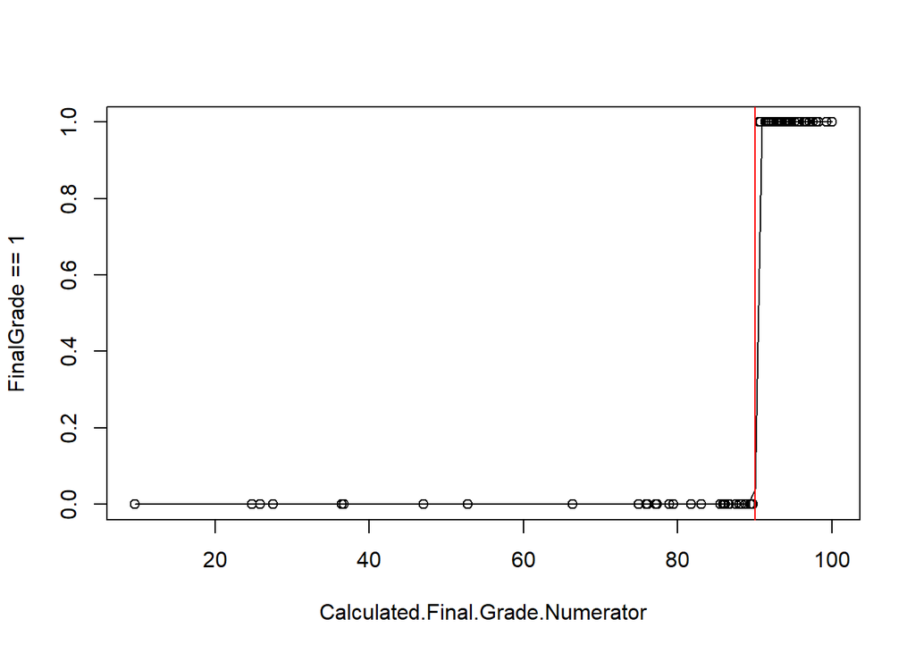

```r
# Draw the "perfect split"
perfect.glm <- glm(FinalGrade == 1 ~ Calculated.Final.Grade.Numerator, data = grades425, family = binomial)
plot(FinalGrade == 1 ~ Calculated.Final.Grade.Numerator, data = grades425)
b <- perfect.glm$coefficients
curve(exp(b[1] + b[2]*x)/(1 + exp(b[1] + b[2]*x)), add = TRUE)
abline(v = 90, col = "red")
```

Pair plots help in the beginning, but you are really just trying things.

##### Making Predictions

```r
#Best Simple Logistic Regression
best.glm <- glm(FinalGrade == 1 ~ Hard.Work.Subtotal.Numerator, data = grades425, family = binomial)
summary(best.glm)
```

```
##
## Call:
## glm(formula = FinalGrade == 1 ~ Hard.Work.Subtotal.Numerator,
##     family = binomial, data = grades425)
##
## Deviance Residuals:
##     Min       1Q   Median       3Q      Max
## -2.0528  -0.2071   0.5092   0.5237   2.3803
##
## Coefficients:
##                              Estimate Std. Error z value Pr(>|z|)
## (Intercept)                  -24.8724     6.9424  -3.583 0.000340 ***
## Hard.Work.Subtotal.Numerator   0.8950     0.2419   3.700 0.000216 ***
## ---
## Signif. codes:  0 '***' 0.001 '**' 0.01 '*' 0.05 '.' 0.1 ' ' 1
##
## (Dispersion parameter for binomial family taken to be 1)
##
##     Null deviance: 100.857  on 72  degrees of freedom
## Residual deviance:  52.557  on 71  degrees of freedom
## AIC: 56.557
##
## Number of Fisher Scoring iterations: 7
```

```r
plot(FinalGrade == 1 ~ Hard.Work.Subtotal.Numerator, data = grades425)
b2 <- best.glm$coefficients
curve(1/(exp(-b2[1] - b2[2] * x) + 1), add = TRUE)

#80% of Skills Quizzes is equal to 30*0.8 = 24 points....
predict(best.glm, data.frame(Hard.Work.Subtotal.Numerator = 24), type = "response")
```

```
##          1
## 0.03252479
```

```r
abline(v = 24, h = 0.03252479, lty = 2, col = "red")

#100% of Skills Quizzes is equal to 30*0.8 = 24 points....
predict(best.glm, data.frame(Hard.Work.Subtotal.Numerator = 30), type = "response")
```

```
##         1
## 0.8783876
```

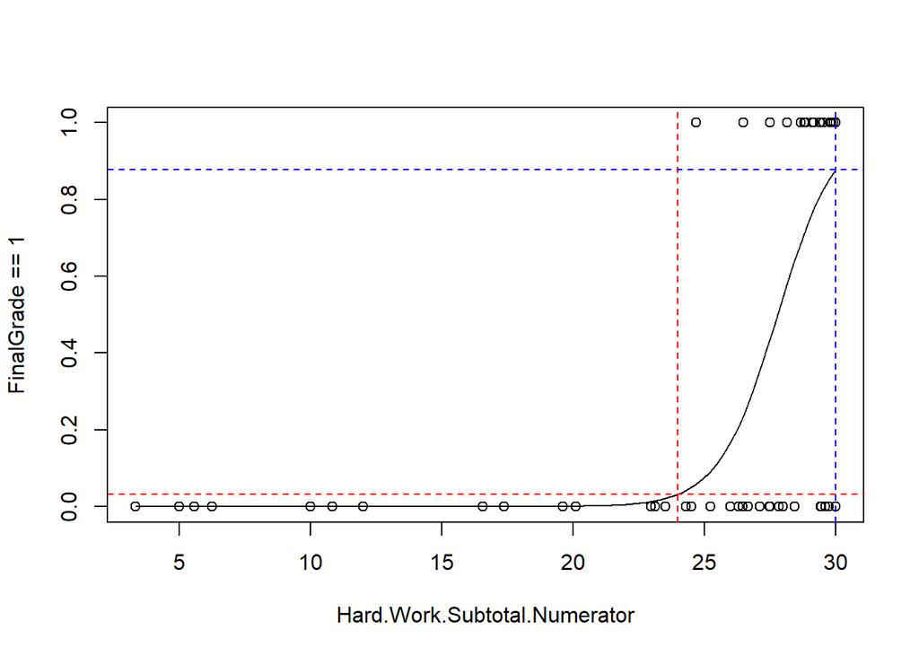

```r
abline(v = 30, h = 0.8783876, lty = 2, col = "blue")
```